# AN588-Week-8

Brooke Rothamer

2023-11-02

# Module 14: Basic Categorical Data Analysis and ANOVA

## Categorical Predictors in Regression

Thus far we have used simple linear regression models involving continuous explanatory variables, but we can also use a discrete or categorical explanatory variable, made up of 2 or more groups that are coded as “factors” (i.e., we use integer values from 1 to k discrete groups as dummy values for our categorical variables). Let’s load in our zombie survivor data again, but this time we specify stringsAsFactors = TRUE and then look at the class of the variable “gender”.

```r
library(curl)
f <- curl("https://raw.githubusercontent.com/fuzzyatelin/fuzzyatelin.github.io/master/AN588_Fall23/zombies.csv")
z <- read.csv(f, header = TRUE, sep = ",", stringsAsFactors = TRUE)
class(z$gender)
```

```
## [1] "factor"
```

```r
summary(z$gender)
```

```
##    Female      Male NonBinary
##       486       495        19
```

As with our prior simple regression analysis, we want to evalute the effect of a predictor variable on a response variable (e.g., “height”), but this time we want our predictor to be a discrete variable (e.g., “gender”) rather than a continuous one. We can start off by plotting “height” by “gender” using the same formula notation we have been using.

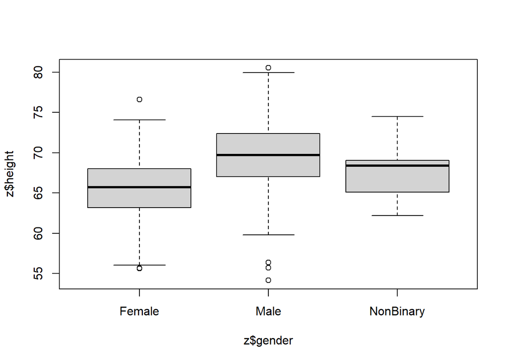

```r
plot(z$height ~ z$gender)
```

Based on our plot, there indeed seems to be a difference in height between genders, with males appearing taller, non-binary folks of middling height, and females at the shorter end of the distribution. We can test this directly using linear regression (and, recall, we already know another way to test this, using z or t tests to compare means).

```r
m <- lm(data = z, height ~ gender)
summary(m)
```

```
##
## Call:
## lm(formula = height ~ gender, data = z)
##
## Residuals:
##      Min       1Q   Median       3Q      Max
## -15.4743  -2.5172   0.1484   2.5292  11.0160
##
## Coefficients:
##                 Estimate Std. Error t value Pr(>|t|)
## (Intercept)      65.5888     0.1734 378.308  < 2e-16 ***
## genderMale        4.0349     0.2441  16.532  < 2e-16 ***
## genderNonBinary   2.3143     0.8938   2.589  0.00976 **
## ---
## Signif. codes:  0 '***' 0.001 '**' 0.01 '*' 0.05 '.' 0.1 ' ' 1
##
## Residual standard error: 3.822 on 997 degrees of freedom
## Multiple R-squared:  0.2152, Adjusted R-squared:  0.2136
## F-statistic: 136.7 on 2 and 997 DF,  p-value: < 2.2e-16
```

If we take a look at the summary() of our model, m, we see the same kind of table of results we have seen before, but because the predictor variable in this case is a factor vector instead of a numeric vector, the coefficients are reported and interpreted a bit differently. The coefficient for the intercept, i.e., β0, reflects the estimate of the mean height for the first of our level variables (in this case, Female). The other categories are then compared relative to female.

```r
levels(z$gender)
```

```
## [1] "Female"    "Male"      "NonBinary"
```

The estimate for β1 is reported as “genderMale” and the value for that coefficient, 4.0349, is the estimated difference in mean height associated with being a male compared to a female. The regression equation is basically:

**height = 65.5888 + 4.0349 x gender**, with males assigned a gender value of 1 and females of 0.

In this case, the p value associated with the t statistic for β1 is extremely low, so we conclude that “gender” has a significant effect on height.

We can easily relevel() what is the baseline group (this becomes much more useful as we get more categorical variables in our regressions). The result is very similar, but the sign of β1 is changed.

```r
z$gender <- relevel(z$gender, ref = "Male") #re-levels to make male the reference level
m <- lm(data = z, height ~ gender)
summary(m)
```

```
##
## Call:
## lm(formula = height ~ gender, data = z)
##
## Residuals:
##      Min       1Q   Median       3Q      Max
## -15.4743  -2.5172   0.1484   2.5292  11.0160
##
## Coefficients:
##                 Estimate Std. Error t value Pr(>|t|)
## (Intercept)      69.6238     0.1718 405.282   <2e-16 ***
## genderFemale     -4.0349     0.2441 -16.532   <2e-16 ***
## genderNonBinary  -1.7206     0.8935  -1.926   0.0544 .
## ---
## Signif. codes:  0 '***' 0.001 '**' 0.01 '*' 0.05 '.' 0.1 ' ' 1
##
## Residual standard error: 3.822 on 997 degrees of freedom
## Multiple R-squared:  0.2152, Adjusted R-squared:  0.2136
## F-statistic: 136.7 on 2 and 997 DF,  p-value: < 2.2e-16
```

```r
p <- 1 - pf(276.9, df1 = 1, df2 = 998)
p
```

```
## [1] 0
```

We can extend this approach to the case where we have more than two categories for a variable… in this case we need to dummy code our factor variable into multiple binary variables. R takes care of this for us automatically, but it is good to recognize the procedure.

Let’s explore this by recoding the variable “major” into four levels. We first create a new variable name.

```r
z$occupation <- "temp"
```

We can use the unique() or levels() function to list all of the different majors in our dataset. The latter does this alphabetically. The row() command returns an index of row numbers, which we can then use to recode “major” into our new variable.

```r
unique(z$major)
```

```
##  [1] medicine/nursing                      criminal justice administration
##  [3] education                             energy studies
##  [5] logistics                             psychology
##  [7] botany                                communication
##  [9] military strategy                     economics
## [11] mechanical engineering                physical education
## [13] philosophy                            biology
## [15] applied sciences                      animal husbandry
## [17] agricultural sciences                 culinart services
## [19] city planning                         integrated water resources management
## [21] pharmacology                          environmental science
## [23] human services                        epidemiology
## [25] business administration               architecture
## 26 Levels: agricultural sciences animal husbandry ... psychology
```

```r
levels(z$major)
```

```
##  [1] "agricultural sciences"
##  [2] "animal husbandry"
##  [3] "applied sciences"
##  [4] "architecture"
##  [5] "biology"
##  [6] "botany"
##  [7] "business administration"
##  [8] "city planning"
##  [9] "communication"
## [10] "criminal justice administration"
## [11] "culinart services"
## [12] "economics"
## [13] "education"
## [14] "energy studies"
## [15] "environmental science"
## [16] "epidemiology"
## [17] "human services"
## [18] "integrated water resources management"
## [19] "logistics"
## [20] "mechanical engineering"
## [21] "medicine/nursing"
## [22] "military strategy"
## [23] "pharmacology"
## [24] "philosophy"
## [25] "physical education"
## [26] "psychology"
```

```r
row(data.frame(levels(z$major)))
```

```
##       [,1]
##  [1,]    1
##  [2,]    2
##  [3,]    3
##  [4,]    4
##  [5,]    5
##  [6,]    6
##  [7,]    7
##  [8,]    8
##  [9,]    9
## [10,]   10
## [11,]   11
## [12,]   12
## [13,]   13
## [14,]   14
## [15,]   15
## [16,]   16
## [17,]   17
## [18,]   18
## [19,]   19
## [20,]   20
## [21,]   21
## [22,]   22
## [23,]   23
## [24,]   24
## [25,]   25
## [26,]   26
```

```r
z$occupation[row(data.frame(levels(z$major))) %in% c(1, 2, 3, 5, 6, 14, 15, 16, 18, 21, 23)] <- "natural science"
z$occupation[row(data.frame(levels(z$major))) %in% c(7, 8, 12, 17, 19, 22)] <- "logistics"
z$occupation[row(data.frame(levels(z$major))) %in% c(4, 18, 20)] <- "engineering"
z$occupation[row(data.frame(levels(z$major))) %in% c(9, 10, 11, 13, 24, 25, 26)] <- "other"
z$occupation <- as.factor(z$occupation)
levels(z$occupation)
```

```
## [1] "engineering"     "logistics"       "natural science" "other"
```

```r
z$occupation <- relevel(z$occupation, ref = "natural science")
levels(z$occupation)
```

```
## [1] "natural science" "engineering"     "logistics"       "other"
```

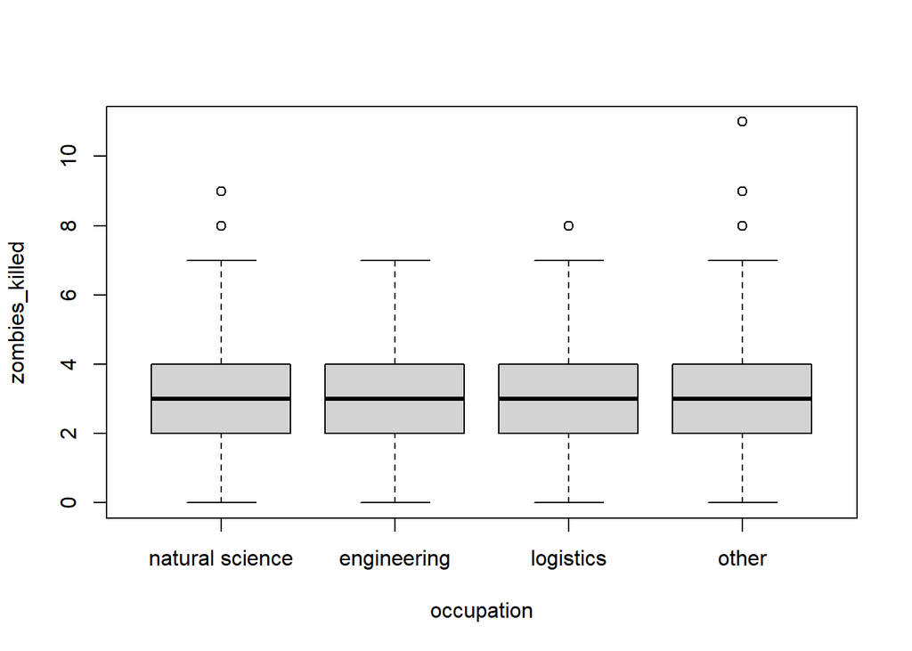

```r
plot(data = z, zombies_killed ~ occupation)
```

```r
m <- lm(data = z, zombies_killed ~ occupation-1) #Great note from Jimmy: including a -1 at the end means that the linear model will use 0 as a baseline instead of one of the categories! The baseline is assuming no occupation (But you might still need to do it without the -1 to see the difference between each occupation)
summary(m)
```

```
##
## Call:
## lm(formula = zombies_killed ~ occupation - 1, data = z)
##
## Residuals:
##     Min      1Q  Median      3Q     Max
## -3.0234 -1.0234 -0.0234  0.9827  7.9926
##
## Coefficients:
##                           Estimate Std. Error t value Pr(>|t|)
## occupationnatural science  3.02338    0.08917   33.91   <2e-16 ***
## occupationengineering      2.80000    0.16316   17.16   <2e-16 ***
## occupationlogistics        3.01732    0.11512   26.21   <2e-16 ***
## occupationother            3.00743    0.10668   28.19   <2e-16 ***
## ---
## Signif. codes:  0 '***' 0.001 '**' 0.01 '*' 0.05 '.' 0.1 ' ' 1
##
## Residual standard error: 1.75 on 996 degrees of freedom
## Multiple R-squared:  0.746,  Adjusted R-squared:  0.745
## F-statistic: 731.4 on 4 and 996 DF,  p-value: < 2.2e-16
```

```r
p <- 1 - pf(0.526, df1 = 3, df2 = 996)  # F test
p
```

```
## [1] 0.6644926
```

In this case, we see no significant effect of major on zombie killing proficiency.

## One-Way ANOVA

Regression with a single categorical predictor run as we have just done above is exactly equivalent to a “one-way” or “one-factor” analysis of variance, or ANOVA. That is, ANOVA is just one type of special case of least squares regression.

We can thus run an ANOVA with one line in R. Compare the results presented in the summary() output table from an ANOVA with that from the global test reported in summary() from lm()

```r
m <- aov(data = z, zombies_killed ~ occupation)
summary(m)
```

```
##              Df Sum Sq Mean Sq F value Pr(>F)
## occupation    3    4.8   1.610   0.526  0.665
## Residuals   996 3049.1   3.061
```

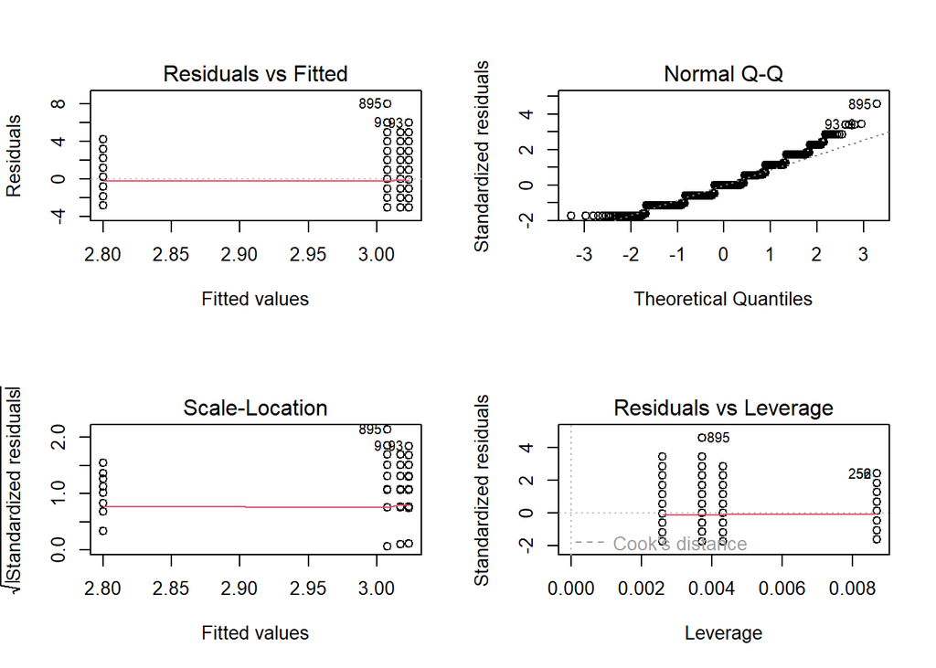

```r
par(mfrow = c(2, 2))
plot(m)
```

In general, in ANOVA and simple regression using a single categorical variable, we aim to test the H0 that the means of a variable of interest do not differ among groups, i.e., that μ1 = μ2… μk are all equal. This is an extension of our comparison of two means that we did with z and t tests.

The basic linear model formulation for ANOVA is:

Yi,j = μ + βiXi + ϵi,j

Where:

- μ is the grand population mean
- βi is the deviation of the mean of treatment level i from the grand mean
- ϵi,j is error variance of individual points from the grand mean

The assumptions of ANOVA, similar to those of simple regression, are:

- that samples are independent and identically distributed
- that the residuals ϵi,j are normally distributed
- that within-group variances are similar across all groups (’homoscedastic”)

The following assumption makes the interpretation of results from ANOVA more straightforward, but it is not strictly required.

- Our experiment/observations have a balanced design (i.e., an equal number of cases in all groups). If this is violated, it ceases to be true that the total SS of our dataset = within SS + between SS, and then the calculations of MSE and F and our associated p values would be off.

### Challenge 1

Is the omnibus test of the relationship between age category and femur length significant? Are femur lengths significantly different for juveniles versus subadults? Subadults versus adults? Juveniles versus adults? HINT: to test these bivariate options, you will need to relevel() your factors for simple linear regression.

```r
library(curl)
library(dplyr)
f <- curl("https://raw.githubusercontent.com/fuzzyatelin/fuzzyatelin.github.io/master/AN588_Fall21/gibbon-femurs.csv")
d <- read.csv(f, header = TRUE, sep = ",", stringsAsFactors = TRUE)
d$age <- factor(d$age, levels = c("inf", "juv", "subadult", "adult"))  #this reorders the age levels so that they're in order
head(d)
```

```
##   id age    sex femur.length
## 1  1 inf female         7.28
## 2  2 inf   male         6.30
## 3  3 inf female         7.44
## 4  4 inf   male         8.69
## 5  5 inf female         9.13
## 6  6 inf   male         9.28
```

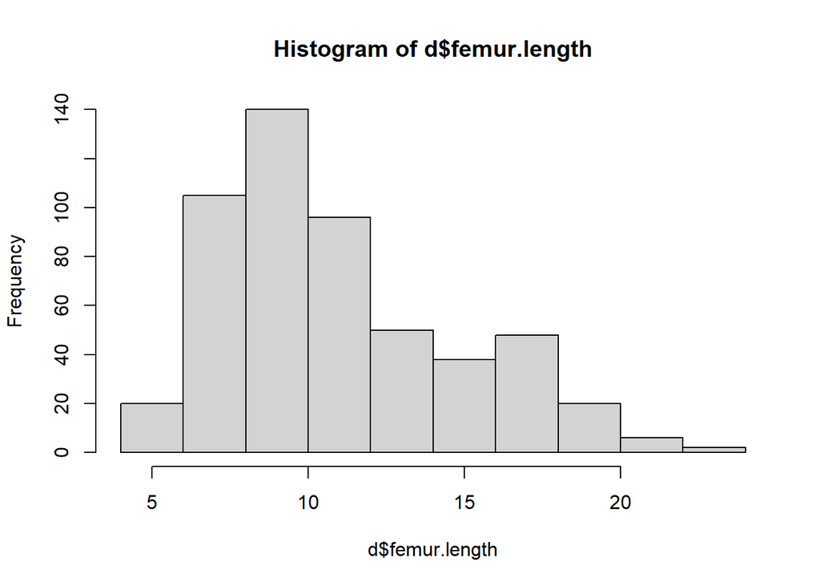

```r
hist(d$femur.length)
```

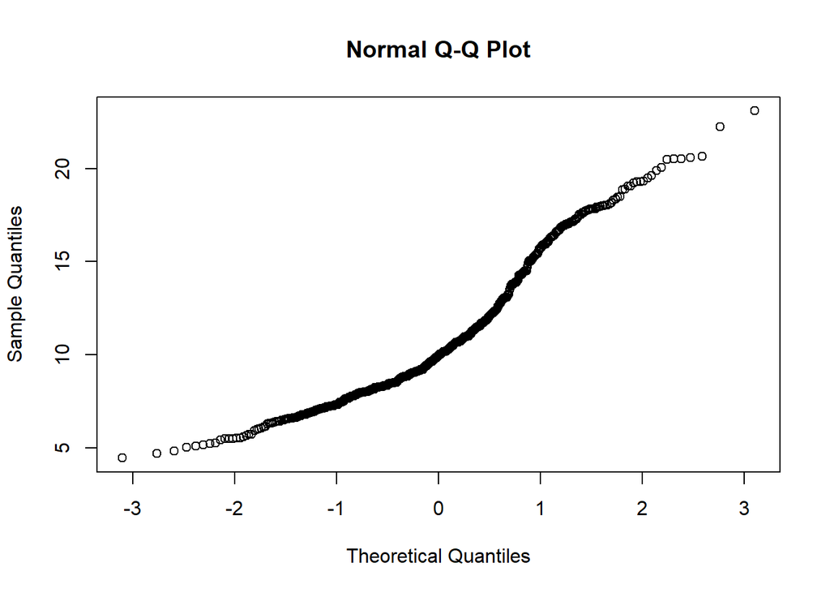

```r
qqnorm(d$femur.length)
```

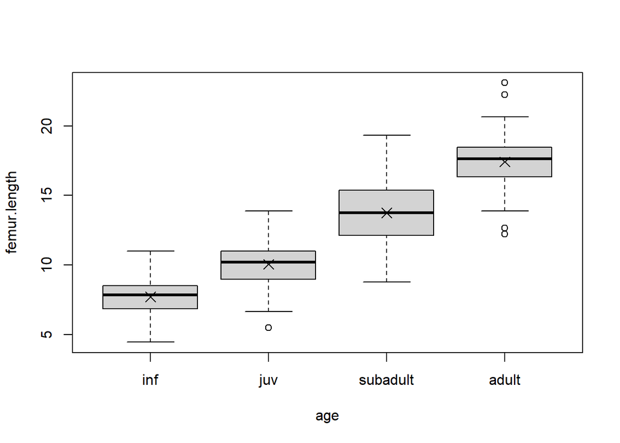

```r
plot(data = d, femur.length ~ age)  # boxplot with medians
means <- summarise(group_by(d, age), mean(femur.length))  # calculate average by group
points(1:4, means$`mean(femur.length)`, pch = 4, cex = 1.5)  # add means to plot
```

```r
sds <- summarise(group_by(d, age), sd(femur.length))
max(sds$`sd(femur.length)`)/min(sds$`sd(femur.length)`)  # check that variances are roughly equal (ratio of max/min is <2)
```

```
## [1] 1.767635
```

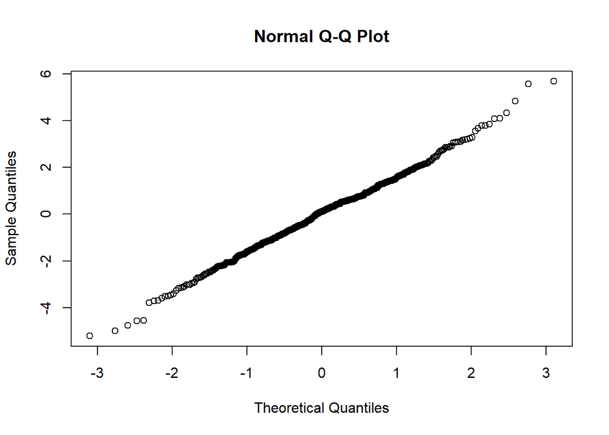

```r
means.centered <- d$femur.length - means[as.numeric(d$age), 2]  # subtract relevant group mean from each data point
qqnorm(means.centered$`mean(femur.length)`)  # graphical tests for normality
```

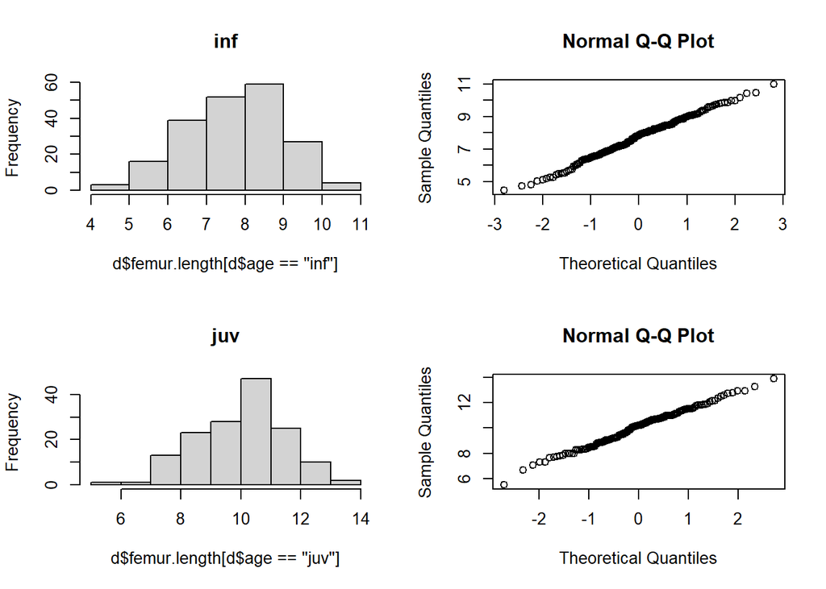

```r
par(mfrow = c(2, 2))
hist(d$femur.length[d$age == "inf"], main = "inf")
qqnorm(d$femur.length[d$age == "inf"])
hist(d$femur.length[d$age == "juv"], main = "juv")
qqnorm(d$femur.length[d$age == "juv"])
```

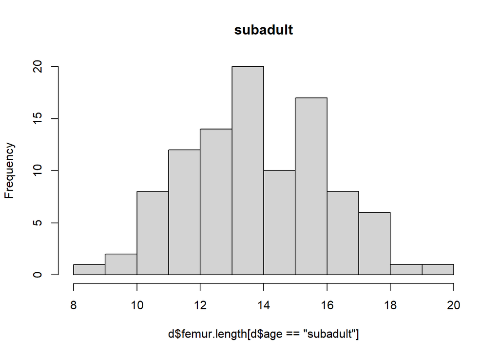

```r
hist(d$femur.length[d$age == "subadult"], main = "subadult")
```

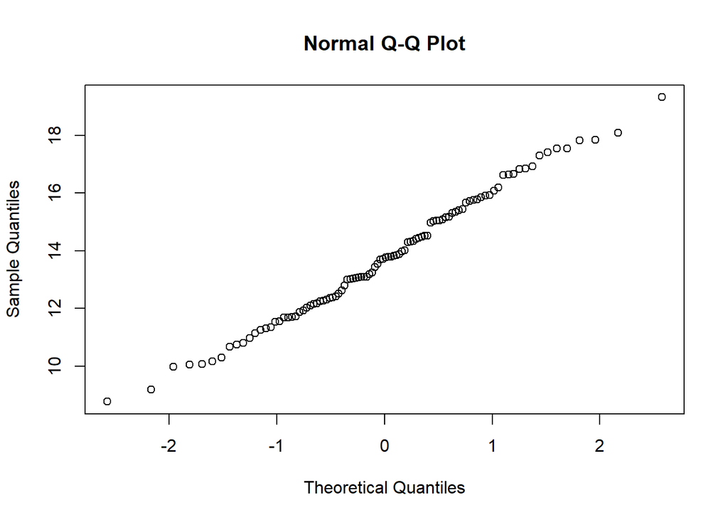

```r
qqnorm(d$femur.length[d$age == "subadult"])
```

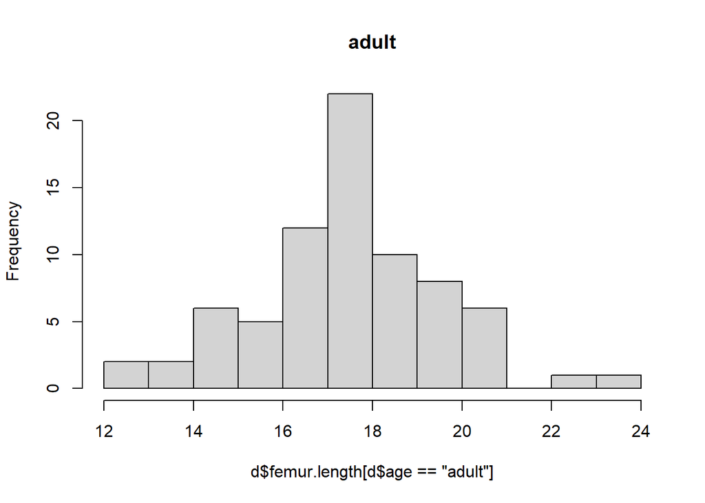

```r
hist(d$femur.length[d$age == "adult"], main = "adult")
```

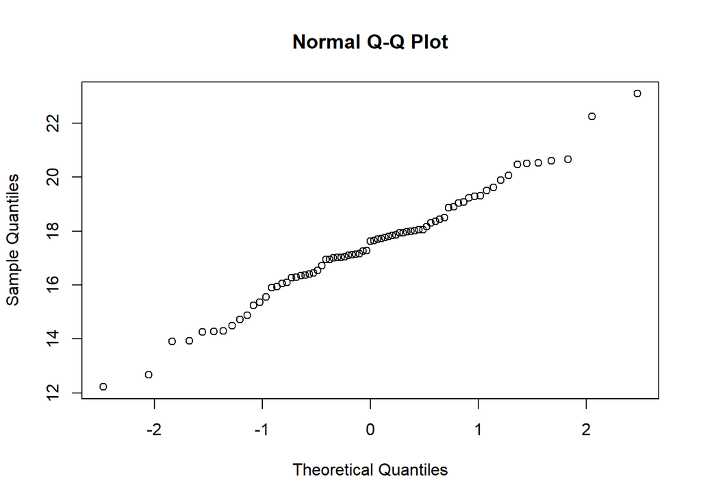

```r
qqnorm(d$femur.length[d$age == "adult"])
```

All this checking done, we can plot our data by group and run our ANOVA model…

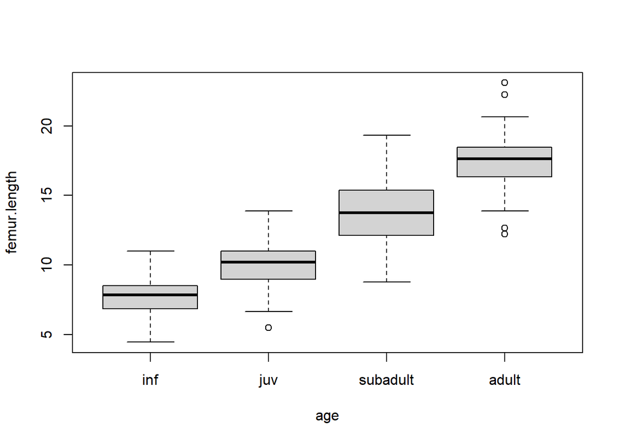

```r
par(mfrow = c(1, 1))
plot(data = d, femur.length ~ age)
```

```r
m <- aov(data = d, femur.length ~ age)  # femur length related to age
summary(m)
```

```
##              Df Sum Sq Mean Sq F value Pr(>F)
## age           3   6152  2050.6   735.8 <2e-16 ***
## Residuals   521   1452     2.8
## ---
## Signif. codes:  0 '***' 0.001 '**' 0.01 '*' 0.05 '.' 0.1 ' ' 1
```

```r
m <- lm(data = d, femur.length ~ age)
summary(m)
```

```
##
## Call:
## lm(formula = femur.length ~ age, data = d)
##
## Residuals:
##     Min      1Q  Median      3Q     Max
## -5.2052 -1.1105  0.1089  1.0395  5.6748
##
## Coefficients:
##             Estimate Std. Error t value Pr(>|t|)
## (Intercept)   7.7105     0.1180   65.32   <2e-16 ***
## agejuv        2.3406     0.1803   12.98   <2e-16 ***
## agesubadult   6.0459     0.2045   29.57   <2e-16 ***
## ageadult      9.7147     0.2260   42.98   <2e-16 ***
## ---
## Signif. codes:  0 '***' 0.001 '**' 0.01 '*' 0.05 '.' 0.1 ' ' 1
##
## Residual standard error: 1.669 on 521 degrees of freedom
## Multiple R-squared:  0.809,  Adjusted R-squared:  0.8079
## F-statistic: 735.8 on 3 and 521 DF,  p-value: < 2.2e-16
```

## Post-Hoc Tests and the Non-Parametric Kruskal-Wallis Test

After finding a significant omnibus F statistic in an ANOVA, we can test, post-hoc, what group means are different from one another using pairwise t tests with appropriate p value correction.

```r
pairwise.t.test(d$femur.length, d$age, p.adj = "bonferroni")
```

```
##
##  Pairwise comparisons using t tests with pooled SD
##
## data:  d$femur.length and d$age
##
##          inf    juv    subadult
## juv      <2e-16 -      -
## subadult <2e-16 <2e-16 -
## adult    <2e-16 <2e-16 <2e-16
##
## P value adjustment method: bonferroni
```

After an ANOVA, we can also use a “Tukey Honest Significant Differences” test to evaluate this.

```r
m <- aov(d$femur.length ~ d$age)
posthoc <- TukeyHSD(m, "d$age", conf.level = 0.95)
posthoc  # all age-sex classes differ
```

```
##   Tukey multiple comparisons of means
##     95% family-wise confidence level
##
## Fit: aov(formula = d$femur.length ~ d$age)
##
## $`d$age`
##                    diff      lwr       upr p adj
## juv-inf        2.340617 1.875875  2.805359     0
## subadult-inf   6.045950 5.518982  6.572918     0
## adult-inf      9.714750 9.132165 10.297335     0
## subadult-juv   3.705333 3.149860  4.260806     0
## adult-juv      7.374133 6.765643  7.982623     0
## adult-subadult 3.668800 3.011556  4.326044     0
```

The Kruskal-Wallis test is a **nonparametric alternative to one-way ANOVA** that relaxes the need for normality in the distribution of data in each group (the different groups should still have roughly equal variances, though). Essentially, rather than testing the null hypothesis that the means for each group do not differ we are instead testing the null hypothesis that the **medians** do not differ. The test converts the continuous response variable to a set of RANKS (i.e., it does a uniform transformation) and then works with those ranks. The p value associated with the K-W test statistic is evaluated against a Chi-Square distribution.

```r
m <- kruskal.test(data = d, femur.length ~ age)
m
```

```
##
##  Kruskal-Wallis rank sum test
##
## data:  femur.length by age
## Kruskal-Wallis chi-squared = 407.13, df = 3, p-value < 2.2e-16
```

```r
d <- arrange(d, femur.length)  # use {dplyr} to sort by femur.length
d <- mutate(d, femur.rank = row(data.frame(d$femur.length)))  # use {dplyr} to add new variable of rank femur.length
m <- kruskal.test(data = d, femur.rank ~ age)
m
```

```
##
##  Kruskal-Wallis rank sum test
##
## data:  femur.rank by age
## Kruskal-Wallis chi-squared = 407.43, df = 3, p-value < 2.2e-16
```

## Multiple Factor ANOVA

Sometimes the data we are interested in is characterized by multiple grouping variables (e.g., age and sex). In the case of the gibbon femur length data, we are interested in the main effect of each factor on the variable of interest (e.g., do femur lengths vary by age or sex) while accounting for the effects of the other factor. We may also be interested in any interactive effects among factors. Thus, in multiple factor ANOVA we are interested in testing several null hypotheses simultaneously: [1] that each factor has no effect on the mean of our continuous reponse variable and [2] that there are no interactive effects of sets of factors on the mean of our continuous reponse variable.

Model description and testing for multiple ANOVA is a simple extension of the formula notation which we’ve used for single factors. **First, though, let’s quickly check that our groups have similar variance**. (or else, we could not just use parametric analysis)

```r
library(ggplot2)
means <- summarise(group_by(d, age, sex), mean(femur.length))  # first we calculate averages by combination of factors
```

[output not shown]

```r
means
```

```
## # A tibble: 8 × 3
## # Groups:   age [4]
##   age      sex    `mean(femur.length)`
##   <fct>    <fct>                 <dbl>
## 1 inf      female                 7.83
## 2 inf      male                   7.59
## 3 juv      female                 9.98
## 4 juv      male                  10.1
## 5 subadult female                12.7
## 6 subadult male                  14.6
## 7 adult    female                16.7
## 8 adult    male                  18.4
```

```r
sds <- summarise(group_by(d, age, sex), sd(femur.length))  # first we calculate averages by combination of factors
```

[output not shown]

```r
sds
```

```
## # A tibble: 8 × 3
## # Groups:   age [4]
##   age      sex    `sd(femur.length)`
##   <fct>    <fct>               <dbl>
## 1 inf      female               1.22
## 2 inf      male                 1.31
## 3 juv      female               1.44
## 4 juv      male                 1.53
## 5 subadult female               1.62
## 6 subadult male                 2.30
## 7 adult    female               1.79
## 8 adult    male                 2.00
```

Bit of an increase in differences in mean with age. Bit of an increase in standard deviation and difference in standard deviation between sexes with age.

```r
max(sds$`sd(femur.length)`)/min(sds$`sd(femur.length)`)  # check that variances in each group are roughly equal (ratio of max/min is <2)
```

```
## [1] 1.882171
```

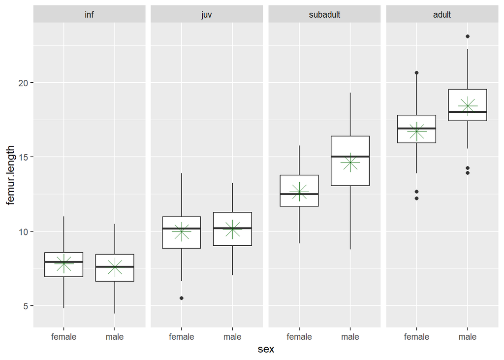

```r
p <- ggplot(data = d, aes(y = femur.length, x = sex)) + geom_boxplot() + facet_wrap(~age,
    ncol = 4)  # and let's plot what the data look like
# p <- p + geom_point() # uncommenting this shows all points
p <- p + stat_summary(fun.y = mean, colour = "darkgreen", geom = "point", shape = 8,
    size = 6)
p
```

If we look at each variable separately using ANOVA, we see there is an effect of age but not of sex.

```r
summary(aov(data = d, femur.length ~ age))
```

```
##              Df Sum Sq Mean Sq F value Pr(>F)
## age           3   6152  2050.6   735.8 <2e-16 ***
## Residuals   521   1452     2.8
## ---
## Signif. codes:  0 '***' 0.001 '**' 0.01 '*' 0.05 '.' 0.1 ' ' 1
```

```r
summary(aov(data = d, femur.length ~ sex))
```

```
##              Df Sum Sq Mean Sq F value Pr(>F)
## sex           1     28   28.33   1.956  0.163
## Residuals   523   7576   14.48
```

However, if we do a two-way ANOVA and consider the factors together, we see that there is still a main effect of age when taking sex into account and there is a main effect of sex when we take age into account.

```r
m <- summary(aov(data = d, femur.length ~ age + sex))
m
```

```
##              Df Sum Sq Mean Sq F value   Pr(>F)
## age           3   6152  2050.6   756.4  < 2e-16 ***
## sex           1     42    42.3    15.6 8.89e-05 ***
## Residuals   520   1410     2.7
## ---
## Signif. codes:  0 '***' 0.001 '**' 0.01 '*' 0.05 '.' 0.1 ' ' 1
```

To examine whether there is an interaction effect, we would modify our model formula a bit…

```r
m <- aov(data = d, femur.length ~ age + sex + age:sex)  # : operator includes specific interaction terms
summary(m)
```

```
##              Df Sum Sq Mean Sq F value   Pr(>F)
## age           3   6152  2050.6  816.35  < 2e-16 ***
## sex           1     42    42.3   16.84 4.72e-05 ***
## age:sex       3    111    37.0   14.73 3.21e-09 ***
## Residuals   517   1299     2.5
## ---
## Signif. codes:  0 '***' 0.001 '**' 0.01 '*' 0.05 '.' 0.1 ' ' 1
```

We could also use…

```r
m <- aov(data = d, femur.length ~ age * sex)  #(can continue to add more things with *)
summary(m)
```

```
##              Df Sum Sq Mean Sq F value   Pr(>F)
## age           3   6152  2050.6  816.35  < 2e-16 ***
## sex           1     42    42.3   16.84 4.72e-05 ***
## age:sex       3    111    37.0   14.73 3.21e-09 ***
## Residuals   517   1299     2.5
## ---
## Signif. codes:  0 '***' 0.001 '**' 0.01 '*' 0.05 '.' 0.1 ' ' 1
```

```r
m <- lm(data = d, femur.length ~ age * sex)  # or using the lm() function...
summary(m)
```

```
##
## Call:
## lm(formula = femur.length ~ age * sex, data = d)
##
## Residuals:
##     Min      1Q  Median      3Q     Max
## -5.8727 -1.0088  0.1336  1.0469  4.6773
##
## Coefficients:
##                     Estimate Std. Error t value Pr(>|t|)
## (Intercept)           7.8250     0.1562  50.107  < 2e-16 ***
## agejuv                2.1514     0.2354   9.140  < 2e-16 ***
## agesubadult           4.8481     0.2832  17.118  < 2e-16 ***
## ageadult              8.8909     0.2854  31.148  < 2e-16 ***
## sexmale              -0.2363     0.2242  -1.054    0.293
## agejuv:sexmale        0.3986     0.3431   1.162    0.246
## agesubadult:sexmale   2.2059     0.3896   5.662 2.48e-08 ***
## ageadult:sexmale      1.9523     0.4341   4.498 8.48e-06 ***
## ---
## Signif. codes:  0 '***' 0.001 '**' 0.01 '*' 0.05 '.' 0.1 ' ' 1
##
## Residual standard error: 1.585 on 517 degrees of freedom
## Multiple R-squared:  0.8292, Adjusted R-squared:  0.8269
## F-statistic: 358.6 on 7 and 517 DF,  p-value: < 2.2e-16
```

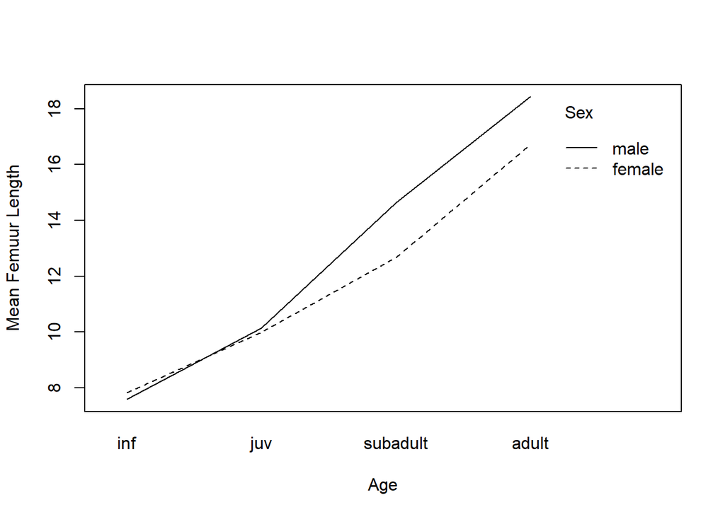

```r
interaction.plot(x.factor = d$age, xlab = "Age", trace.factor = d$sex, trace.label = "Sex",
    response = d$femur.length, fun = mean, ylab = "Mean Femuur Length")
```

Here, it looks like there is indeed a significant main effect of each term as well as an interaction between our two categorical variables. We will return to comparing models to one another (e.g., our model with and without interaction) and to post-hoc tests of what group mean differences are significant when we get into model selection in another few lectures.

Note that the **ORDER in which our factors are entered into our linear model results in different values for the entries in our ANOVA table**, while the estimation of our regression coefficients is identical regardless:

```r
m1 <- aov(data = d, femur.length ~ age * sex)
summary(m1)
```

```
##              Df Sum Sq Mean Sq F value   Pr(>F)
## age           3   6152  2050.6  816.35  < 2e-16 ***
## sex           1     42    42.3   16.84 4.72e-05 ***
## age:sex       3    111    37.0   14.73 3.21e-09 ***
## Residuals   517   1299     2.5
## ---
## Signif. codes:  0 '***' 0.001 '**' 0.01 '*' 0.05 '.' 0.1 ' ' 1
```

```r
m2 <- aov(data = d, femur.length ~ sex * age)
summary(m2)
```

```
##              Df Sum Sq Mean Sq F value   Pr(>F)
## sex           1     28    28.3   11.28 0.000843 ***
## age           3   6166  2055.3  818.20  < 2e-16 ***
## sex:age       3    111    37.0   14.73 3.21e-09 ***
## Residuals   517   1299     2.5
## ---
## Signif. codes:  0 '***' 0.001 '**' 0.01 '*' 0.05 '.' 0.1 ' ' 1
```

Why is this? In the first case, we are looking at the variance within each age group that is explained by gender while in the second case we are looking at the variance within each gender that is explained by age… but we have different numbers of observations in our different groups. This is known as an unbalanced design.

By default, the aov() function uses something called Type I Sums of Squares (also called “sequential sum of squares”), which gives greater emphasis to the first factor in the model, leaving only residual variation to the remaining factors. It should be used when you want to first control for one factor, leaving the others to explain only any remaining differences. In a Type I ANOVA, the sums of squares for the first term are calculated around the grand mean of our observations, but the next terms are calculated as residuals around the average of the grand mean and the first group mean. This sequential procedure means our results depend on which term shows up first. This can have a large effect on the sums of squares calculated, and hence on p values, when using an unbalanced design.

By contrast, Type II and Type III Sums of Squares calculate individual observations’ within each group as deviations from the grand mean.

By contrast, **Type II Sum of Squares** compares the main effects of each group, assuming that the interaction between them is minimal. Generally it is a much more appropriate test for comparing main effects and is more appropriate for us to use when there is an unbalanced design.

**Type III Sum of Squares** (or “marginal sum of squares”) is most appropriate when there is a **significant interaction effect**. Since both Type II and Type III ANOVA calculate sums of squares around the grand mean, these are unaffected by sample sizes and do not arbitrarily give preference to one effect over another.

To summarize:

- When our data are balanced, our factors are orthogonal, and all three types of sums of squares give the same results.
- If our data are unbalanced, we should generally be using Type II or Type III Sums of Squares, since we are generally interested in exploring the significance of one factor while controlling for the level of the other factors.
- In general, if there is no significant interaction effect, then Type II is more powerful.
- If interaction is present, then Type II is inappropriate while Type III can still be used, but results need to be interpreted with caution (in the presence of interactions, main effects difficult to interpret).

```r
library(car)
m1 <- aov(data = d, femur.length ~ age + sex)
m1 <- Anova(m1, type = "II")
m1
```

```
## Anova Table (Type II tests)
##
## Response: femur.length
##           Sum Sq  Df F value    Pr(>F)
## age       6165.8   3 758.126 < 2.2e-16 ***
## sex         42.3   1  15.604 8.888e-05 ***
## Residuals 1409.7 520
## ---
## Signif. codes:  0 '***' 0.001 '**' 0.01 '*' 0.05 '.' 0.1 ' ' 1
```

## Chi-Square Tests of Goodness of Fit and Independence

### Challenge 2

Let’s return to the zombies dataset, where we defined an occupation based on major for survivors of the zombie apocalypse. We want to test the hypothesis that survivors of the zombie apocalypse are more likely than expected by chance to be natural science majors. We will assume that our null hypothesis is that the proportions of different post-apocalypse occupations are equivalent, i.e., that πnaturalscience = πengineering= πlogistics = πother = 0.25.

```r
obs.table <- table(z$occupation)  # returns the same as summary()
obs.table
```

```
##
## natural science     engineering       logistics           other
##             385             115             231             269
```

```r
exp.table <- rep(0.25 * length(z$occupation), 4)
exp.table
```

```
## [1] 250 250 250 250
```

```r
occupation.matrix <- data.frame(cbind(obs.table, exp.table, (obs.table - exp.table)^2/exp.table))
names(occupation.matrix) <- c("Oi", "Ei", "(Oi-Ei)^2/Ei")
occupation.matrix
```

```
##                  Oi  Ei (Oi-Ei)^2/Ei
## natural science 385 250       72.900
## engineering     115 250       72.900
## logistics       231 250        1.444
## other           269 250        1.444
```

```r
X2 <- sum(occupation.matrix[, 3])
X2
```

```
## [1] 148.688
```

```r
p <- 1 - pchisq(X2, length(obs.table) - 1)
p
```

```
## [1] 0
```

Here, we reject the null hypothesis that the proportions of different occupations among the survivors of the zombie apocalypse is equivalent.

We can do all this with a 1-liner in R, too.

```r
chisq.test(x = obs.table, p = c(0.25, 0.25, 0.25, 0.25))  # here p is a vector of expected proportions... default is uniform
```

```
##
##  Chi-squared test for given probabilities
##
## data:  obs.table
## X-squared = 148.69, df = 3, p-value < 2.2e-16
```

```r
#or

chisq.test(x = obs.table)
```

```
##
##  Chi-squared test for given probabilities
##
## data:  obs.table
## X-squared = 148.69, df = 3, p-value < 2.2e-16
```

The above was a Chi-Square goodness of fit test for one categorical variable… what about if we have two categorical variables and we are curious if there is an association among them? Then we do a Chi-Square test of independence. In this case, our Chi-Square statistic is the sum of (O-E)^2/E across all cells in our table, and our degrees of freedom is = (number of rows - 1) * (number of columns -1). Let’s suppose we want to see if there is a relationship among zombie apocalypse survivors between gender and occupation.

First, we determine our table of observed proportions:

```r
obs.table = table(z$gender, z$occupation)
obs.table
```

```
##
##             natural science engineering logistics other
##   Male                  195          60       122   118
##   Female                184          54       107   141
##   NonBinary               6           1         2    10
```

We can view our data graphically using the mosaic plot() function.

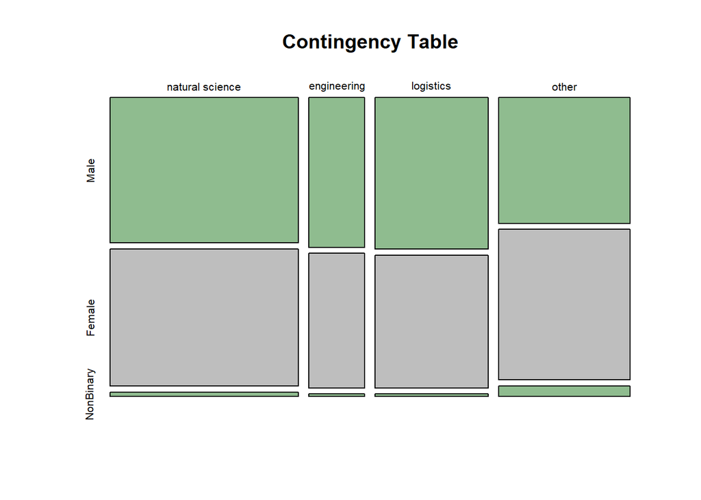

```r
mosaicplot(t(obs.table), main = "Contingency Table", col = c("darkseagreen", "gray"))  # t function transposes the table
```